# Integrated Workflow for Molecular Network Characterization, Spectral Annotation, and Database Curation

Author

Ahlam Mentag, Rebecca Dauwe, Johannes Rainer

## Shiny Documents

This Quarto document presents a workflow for the characterization and visualization of molecular networks. It includes the analysis of known compounds detected in FT-MS data and their corresponding features in QTOF datasets, as well as the visualization of ion trap–based and QTOF-based neutral loss analyses. The document further summarizes the results of CID spectral matching, describes the annotation and incorporation of characterized molecules into the database, and outlines the conversion of the global SQL database into an MGF format compatible with public repositories and analysis platforms for further comparison with external public spectral databases.

## Load required libraries

```r
#' Load required libraries
library(devtools)
library(DBI)
library(RSQLite)
library(here)
library(CompoundDb)
library(MsBackendMgf)
#rm(list = c("convert_compid_assoc"))
#` Uploading RDynLib: Load all functions of the RDynlib directory
load_all()
```

#FTMS flax negative

```r
ft_path <- here("data", "DYL_FLAX_FTMSneg.sqlite")
con <- dbConnect(RSQLite::SQLite(), ft_path)
cspp_ft <- here("data","cspp_flax.txt")
charge_file <- here("data", "ftms_all_compounds_RD.xlsx")
```

We start by the CID spectral matching of 101280 compound from ftms negative database, To do that we need to convert tha database to a spectra object:

```r
dy_sps <- sql_to_spectra(ft_path)
```

```r
cmp <- MultMatchCID_Spectra(
  dy_sps,
  101280,
   spectrum_type_query = "not_assembled",
  spectrum_type_target = "NA",
   ms_level_query = 2,
   ms_level_target = 2,
  polarity_query = 0,
  polarity_target = 0,
  tolerance = 0,
  ppm = 10,
  minIons = ,
    fragments_resolution = "unit.resolution",
  requirePrecursor = T,
)
```

```
'MsBackendCompDb' does not support parallel processing. Switching to serial processing.
'MsBackendCompDb' does not support parallel processing. Switching to serial processing.
```

```r
head(cmp, 5)
```

```
  target_compound_id target_msLevel query_msLevel query_precursorMz
1               1913              2             2            625.14
3               8965              2             2            625.14
4              27345              2             2            625.14
5              37987              2             2            625.14
6              39508              2             2            625.14
  target_precursorMz #FragIon ComIons DotIons
1             625.14      121       6       1
3             625.14      121      14       1
4             625.14      121       4       1
5             625.14      121       4       1
6             625.14      121       3       1
                            target_name target_retention_time
1            quercetin dihexoside AN KM              9.809919
3            quercetin dihexoside AN KM             10.578507
4 myricetin deoxyhexosyl hexoside KA KM              8.230088
5            quercetin dihexoside AN KM             11.799843
6            quercetin dihexoside AN KM             11.970403
  query_retention_time target_expid query_expid
1             24.30053            4         266
3             24.30053           18         266
4             24.30053           84         266
5             24.30053          114         266
6             24.30053          118         266
```

Then we update the cspp table:

```r
cspp.tot_SQL(ft_path, 266, mzerr = 0.01,
                         cspp = cspp_ft, peakwidth = 0.1, IntThres  = 0, mz_tol = 0.5,
                         dot_thresh = 0, spectrum_type = "assembled",
                         min_common = 0, charge_file = charge_file)
```

Update the gnps table:

```r
conv.GNPS_SQL(sql_path= ft_path, expid = 266, peakwidth = 0.2, mzerr = 0.015,
              min = 5, adduct = 60.0211, thr1 = 2, thr2 = 0.1, thr3 = 0.3,
              spectrum_type = "not_assembled", IntThres = 0)
```

Next we visualize the CSPP and GNPS network of 101280 compound from ftms neg:

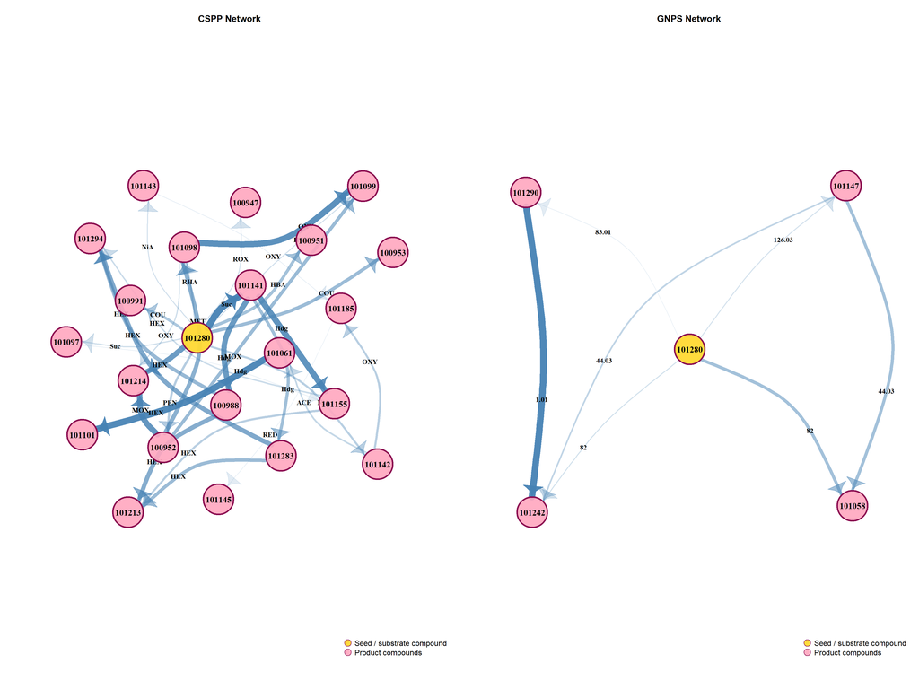

```r
Overall.net_SQL(sql_path = ft_path, exp.id = 266, dbkey = 101280, min = 0,
                nr_of_seq = 3, thr1 = 0.1, thr2 = 0.2, thr3 = 0.3)
```

Now we show the ion trap based analysis of 100988 compound:

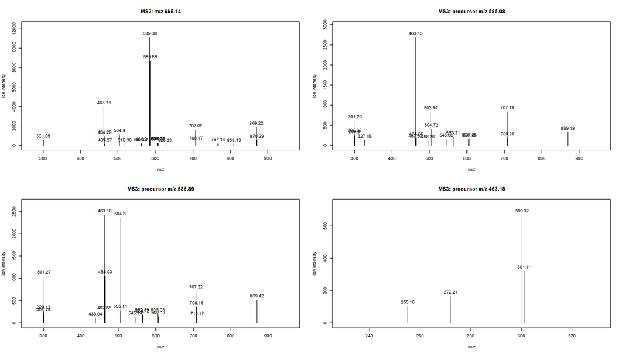

```r
MSnplot_SQL(ft_path, 100988, thr_int = 100)
```

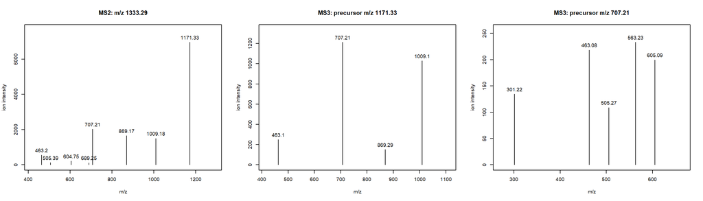

```r
MSnplot_SQL(ft_path, 101155, thr_int = 100)
```

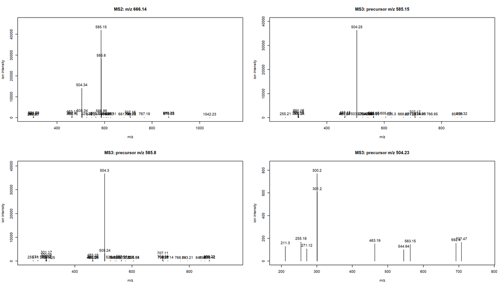

```r
MSnplot_SQL(ft_path, 101283, thr_int = 100)
```

#Qtof flax analysis

Import the database and required files:

```r
qt_path <- here("data", "DYL_FLAX_QTOFneg.sqlite")
con_qt <- dbConnect(RSQLite::SQLite(), qt_path )
neutral_loss_candid <- here("data", "neutral_loss_candid.txt")
neutloss <- read.table(
  neutral_loss_candid,
  header = TRUE,
  sep = "\t",
  stringsAsFactors = FALSE
)

product_ion_candid <- here("data", "product_ion_candid_2.txt")
prdion <- read.table(
  product_ion_candid,
  header = TRUE,
  sep = "\t",
  stringsAsFactors = FALSE
)
```

The aligned compound in qtof data that corresponds to 100988 compound from ftms data:

```r
alignment_file <- here("data", "assoc_flax_63.txt")

getAlignedCompids <- getAlignedCompids_SQL(
compound_id = 100988,
  database_name = "DYL_FLAX_FTMSneg.sqlite",
  alignment_file = alignment_file
)
getAlignedCompids
```

```
  query_compid compid                database
1       100988  45890 DYL_FLAX_QTOFneg.sqlite
```

The 45890 is the qtof compound_id that was aligned with 100988 ftms compound_id.

The msms_spectrum table linked to that compound_id to select the spectrum_id:

```r
list_spectrum <- get_spectrum_id(45890)
list_spectrum
```

```
  spectrum_id ms_level polarity compound_id precursor_mz instrument
1       45965        2        0       45890     666.1409       <NA>
2       45996        2        0       45890     666.1432       <NA>
3       46001        2        0       45890     666.1447       <NA>
4       46217        2        0       45890     666.1409       <NA>
  instrument_type acquisitionNum precScanNum collision_energy predicted splash
1            <NA>           1524          NA          19.4791        NA   <NA>
2            <NA>           1403          NA          29.2187        NA   <NA>
3            <NA>           1328          NA          35.7986        NA   <NA>
4            <NA>           1524          NA          19.4791        NA   <NA>
                                                                                                   dataOrigin
1 C:\\Users\\amentag\\Desktop\\these\\These\\clones\\new_clones\\RDynLib_qtof\\data\\mzml\\S9Ra-neg-DDA3.mzML
2 C:\\Users\\amentag\\Desktop\\these\\These\\clones\\new_clones\\RDynLib_qtof\\data\\mzml\\S1Rb-neg-DDA2.mzML
3 C:\\Users\\amentag\\Desktop\\these\\These\\clones\\new_clones\\RDynLib_qtof\\data\\mzml\\S1Ra-neg-DDA1.mzML
4 C:\\Users\\amentag\\Desktop\\these\\These\\clones\\new_clones\\RDynLib_qtof\\data\\mzml\\S9Ra-neg-DDA3.mzML
```

[output cut: 40 more lines]

We chose the 46001 spectrum_id to show the qtof based neutral loss analysis:

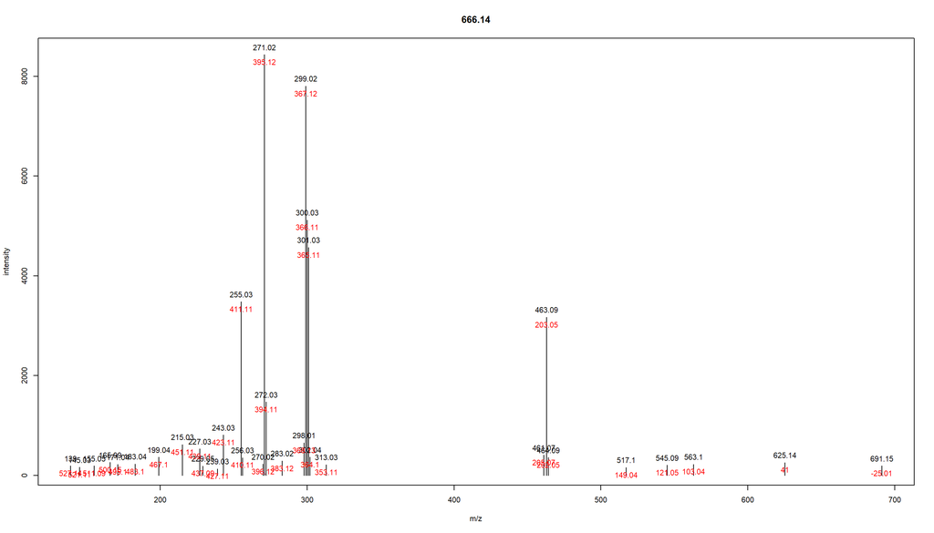

```r
MSMSspecplot_SQL(qt_path, 46001,
                 prdion = prdion, neutloss = neutloss, err = NULL,
                 minum = NULL, nr_col = NULL,   nr_col2 = NULL)
```

Now we enter the characterization of the compounds found to the database:

```r
#EnterName_SQL(ft_path, CoMPID = 101143)
```

```r
#EnterName_SQL(ft_path, CoMPID = 100988)
```

Next, we call the function to export the sql database to an mgf format that could be used for further analysis and comparisons with public databases available on public platforms like: GNPS… We start by converting ftms data

```r
ft_assembled <- here("data", "ft_assembled.mgf")
sql_to_mgf(ft_path, expid = 266, spectrum_type = "assembled",
           output_file = ft_assembled)
```

```
Note: found one or more database tables without defined relationship to other database tables. These are: "Synonym","compound_add","experiment","feature_matrix","gnps_add". You might consider to use the 'addJoinDefinition()' to specify how that table(s) could be joined with the other database tables…
```

Then, we convert qtof data:

```r
qt_assembled <- here("data", "qt_assembled.mgf")
sql_to_mgf(qt_path, expid = 52, spectrum_type = "intersect_single_energy",
           output_file = qt_assembled)
```

```
Note: found one or more database tables without defined relationship to other database tables. These are: "Synonym","compound_add","experiment","feature_matrix","gnps_add". You might consider to use the 'addJoinDefinition()' to specify how that table(s) could be joined with the other database tables…
```